# 基金风格分析

## 总体说明

### 报告内容

基金投资风格的分类是进行基金绩效评估、投资、监管等的重要前提。本报表基于Sharpe法和Fama-Frech三因素模型，对南方中小盘成长基金、安信价值精选基金和嘉实研究阿尔法基金的投资风格进行研究。

### 方法描述

目前对基金的投资风格的定义主要有两种，一种是基金经理的投资目标偏好，即基金经理在资产组合管理过程中，投资于某一类具有共同特征或共同价格行为的股票，比如投资于市盈率较高的公司的股票，或者是执行的某一投资策略。另外Sharpe(1999)的定义更加广泛，其定义为基金经理在资产组合管理过程中采用的某一特定方式或者追求某一特定的投资目标。

基金的风格分析，最早是由诺贝尔经济学奖得主William F. Sharpe提出，并且得到一项著名的研究支持，该研究指出，82只共同基金收益的差异中，有91.5%可以由基金在国库券、债券，以及股票各部分的资产配置上的差别解释。之后的研究发现，在考虑了更大范围内的不同等级的资产配置，有97的基金收益可以由资产配置来解释。

夏普的想法是把基金的收益用代表某个风格的资产的指数进行回归，每个指数的回归系数可以衡量基金在该风格资产的配置。共同基金一般不允许做空，因此约束条件是回归系数是非负，并且各个指数的回归系数加总之和等于1。 表示了由资产风格或资产配置引起的收益率变动。收益率变动剩下的部分是由股票选择或市场择时引起的。夏普的风格分析模型如下：

$$\begin{array}{l} R_{p t}=b_{p 1} F_{1 t}+b_{p 2} F_{12}+\cdots b_{p n} F_{1 n}+\varepsilon_{\mu x} \\ s . t: b_{p 1}+b_{p 2}+\cdots b_{p n}=1 \\ \quad b_{p 1}, b_{p 2} \cdots b_{p n} \geq 0 \end{array}$$

按照 W. Sharpe的定义，上式的残差可以解释基金经理的选择能力，包括股票选择能力和市场时机选择能力，基金收益率减去残差才是由基金的投资风格所决定的。因此，回归因子对基金收益的方差的解释比例，即可决系数可以用来解释基金的资产配置对基金收益的贡献度。

总的来看，基金的风格分析方法可以分为两大类，其一是基于组合特征的分析法，该分析法是通过计算投资组合中的市值规模、市盈率、市净率等特征来判断其投资风格。其二是基于收益的分析法，该分析法的基本思路是：由于基金收益会与某种特定风格投资组合的收益存在高度相关性，所以可以通过检验特定期间基金收益率与各类风格指数的平均风险暴露程度来判断基金风格。

```python
import pandas as pd
import numpy as np
import seaborn as sns
import statsmodels.api as sm
import matplotlib.pyplot as plt
```

```python
import ipywidgets as widgets
from IPython.display import display, HTML
javascript_functions = {False: "hide()", True: "show()"}
button_descriptions  = {False: "Show code", True: "Hide code"}
def toggle_code(state):
    output_string = "<script>$(\"div.input\").{}</script>"
    output_args   = (javascript_functions[state],)
    output        = output_string.format(*output_args)
    display(HTML(output))
def button_action(value):
    state = value.new
    toggle_code(state)
    value.owner.description = button_descriptions[state]
state = False
toggle_code(state)
button = widgets.ToggleButton(state, description = button_descriptions[state])
button.observe(button_action, "value")
display(button)
```

## 导入数据及预处理

```python
indexdata=pd.read_excel('.\data.xlsx',sheet_name='巨潮风格指数')
indexdata=indexdata.drop(0)
funddata=pd.read_excel('.\data.xlsx',sheet_name='基金净值')
funddata=funddata.drop(0)
```

可以画出三基金的净值随年份的变化图。

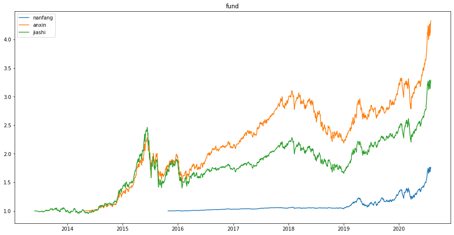

```python
plt.figure(figsize=(16,8))
plt.title('fund')
plt.plot(funddata['日期'],funddata[['南方中小盘成长','安信价值精选','嘉实研究阿尔法']])
plt.legend(['nanfang','anxin','jiashi'])
plt.show()
```

```python
##得到基金收益
funddata['return_nanfang']=funddata['南方中小盘成长'].diff(1)/funddata['南方中小盘成长']
funddata['return_anxin']=funddata['安信价值精选'].diff(1)/funddata['安信价值精选']
funddata['return_jiashi']=funddata['嘉实研究阿尔法'].diff(1)/funddata['嘉实研究阿尔法']
```

```python
####得到指数收益
indexdata['return_stock']=indexdata['万得全A'].diff(1)/indexdata['万得全A']
indexdata['return_bond']=indexdata['万得全A'].diff(1)/indexdata['中债总财富指数']
indexdata['return_B_jc']=indexdata['巨潮大盘'].diff(1)/indexdata['巨潮大盘']
indexdata['return_S_jc']=indexdata['巨潮小盘'].diff(1)/indexdata['巨潮小盘']
indexdata['return_G_jc']=indexdata['巨潮成长'].diff(1)/indexdata['巨潮成长']
indexdata['return_V_jc']=indexdata['巨潮价值'].diff(1)/indexdata['巨潮价值']

indexdata['return_BG']=indexdata['大盘成长'].diff(1)/indexdata['大盘成长']
indexdata['return_BV']=indexdata['大盘价值'].diff(1)/indexdata['大盘价值']
indexdata['return_MG']=indexdata['中盘成长'].diff(1)/indexdata['中盘成长']
indexdata['return_MV']=indexdata['中盘价值'].diff(1)/indexdata['中盘价值']
indexdata['return_SG']=indexdata['小盘成长'].diff(1)/indexdata['小盘成长']
indexdata['return_SV']=indexdata['小盘价值'].diff(1)/indexdata['小盘价值']
```

```python
indexdata.tail()
```

|  | 日期 | 万得全A | 中债总财富指数 | 巨潮大盘 | 巨潮小盘 | 巨潮成长 | 巨潮价值 | 大盘成长 | 大盘价值 | 中盘成长 | ... | return_B_jc | return_S_jc | return_G_jc | return_V_jc | return_BG | return_BV | return_MG | return_MV | return_SG | return_SV |
| --- | --- | --- | --- | --- | --- | --- | --- | --- | --- | --- | --- | --- | --- | --- | --- | --- | --- | --- | --- | --- | --- |
| 4267 | 2020-07-27 00:00:00 | 4998.38 | 196.646 | 4766.5 | 4931.36 | 5128.39 | 6033.47 | 5398.19 | 7184.07 | 5059.16 | ... | 0.00457766 | 0.00183069 | 0.00644075 | -0.000402024 | 0.0102885 | -0.00109662 | -0.00306162 | 0.000353877 | 0.0015867 | 0.00177625 |
| 4268 | 2020-07-28 00:00:00 | 5048.81 | 196.296 | 4812.34 | 4982.13 | 5206.33 | 6054.52 | 5489.97 | 7205.51 | 5115.45 | ... | 0.00952737 | 0.0101904 | 0.0149709 | 0.00347646 | 0.0167179 | 0.00297539 | 0.0110044 | 0.00224754 | 0.0122516 | 0.00684065 |
| 4269 | 2020-07-29 00:00:00 | 5179.57 | 196.095 | 4923.92 | 5120.89 | 5341.72 | 6160.23 | 5631.99 | 7325.56 | 5251.44 | ... | 0.0226601 | 0.0270951 | 0.0253448 | 0.0171607 | 0.0252166 | 0.0163887 | 0.0258957 | 0.0180827 | 0.0251915 | 0.019481 |
| 4270 | 2020-07-30 00:00:00 | 5162.42 | 196.03 | 4898.68 | 5112.66 | 5324.37 | 6124.63 | 5622.03 | 7257.16 | 5214.32 | ... | -0.0051536 | -0.00160803 | -0.00325762 | -0.00581246 | -0.00177112 | -0.00942514 | -0.00711845 | 0.00100759 | -0.00494188 | 0.00234139 |
| 4271 | 2020-07-31 00:00:00 | 5219.5 | 195.724 | 4937.65 | 5174.7 | 5384.36 | 6148.34 | 5681.82 | 7271.32 | 5271.85 | ... | 0.00789349 | 0.0119881 | 0.0111398 | 0.00385627 | 0.010523 | 0.00194679 | 0.0109124 | 0.00499841 | 0.0143046 | 0.0105931 |

5 rows × 25 columns

实际上FAMA三因子模型中的'SMB'和'HML'公式如下：

- SMB =1/3 (Small Value + Small Neutral + Small Growth)－1/3 (Big Value + Big Neutral + Big Growth)
- HML = 1/2 (Small Value + Big Value)－1/2 (Small Growth + Big Growth)

由于我们的数据中为'大盘成长', '大盘价值', '中盘成长', '中盘价值', '小盘成长', '小盘价值'，所以我们定义如下：

```python
indexdata['SMB']=1/2*((indexdata['return_SG']+indexdata['return_SV'])-(indexdata['return_BG']+indexdata['return_BV']))
indexdata['HML']=1/3*((indexdata['return_BV']+indexdata['return_MV']+indexdata['return_SV'])-(indexdata['return_BG']+indexdata['return_MG']+indexdata['return_SG']))
```

```python
alldata=pd.merge(indexdata,funddata)
alldata.columns

returndata=alldata[['日期','return_stock', 'return_bond', 'return_B_jc',
       'return_S_jc', 'return_G_jc', 'return_V_jc', 'return_BG', 'return_BV',
       'return_MG', 'return_MV', 'return_SG', 'return_SV', 'SMB', 'HML',
       'return_nanfang', 'return_anxin','return_jiashi']]
returndata=returndata.set_index('日期')
returndata=returndata.dropna(subset=['return_stock']).apply(lambda x:x.astype(float))
```

网上查找三支基金的资产配置变动以得到FAMA法中相应的'MKT'收益。根据网上的基金资料显示，南方中小盘成长的资产配置在不同时间段有较大变动，所以根据网络的数据引入了不同时间的持仓比例。而安信价值精选和嘉实研究阿尔法的资产配置变动不大，所以我们在计算安信价值精选时按照股票：债券：现金=0.9:0:0.1来计算；嘉实研究阿尔法按照股票：债券：现金=0.9:0.05:0.05来计算。

```python
nanfang=pd.read_excel('E:\。。。\找实习\华泰\data.xlsx',sheet_name='南方资产配置')
print(nanfang.tail())
returndata=pd.merge(returndata,nanfang,how='left',on='日期')
returndata=returndata.set_index('日期')
returndata['股票']=returndata['股票'].fillna(method='ffill')
returndata['股票']=returndata['股票'].fillna(method='bfill')
returndata['债券']=returndata['债券'].fillna(method='ffill')
returndata['债券']=returndata['债券'].fillna(method='bfill')
returndata['stock']=returndata['股票']/(returndata['股票']+returndata['债券'])
returndata['bond']=returndata['债券']/(returndata['股票']+returndata['债券'])
returndata['cash']=1-returndata['stock']-returndata['bond']

returndata['MKT_nanfang']=returndata['return_stock']*returndata['stock']+returndata['return_bond']*returndata['bond']+(1.015**(1/200)-1)*returndata['cash']-(1.015**(1/200)-1)
returndata['MKT_anxin']=returndata['return_stock']*0.9+returndata['return_bond']*0+(1.015**(1/200)-1)*0.1-(1.015**(1/200)-1)
returndata['MKT_jiashi']=returndata['return_stock']*0.9+returndata['return_bond']*0.05+(1.015**(1/200)-1)*0.05-(1.015**(1/200)-1)
```

```
           日期      股票      债券      现金     净值
15 2016-12-31  0.0987  0.3713  0.5903  27.34
16 2016-09-30  0.0797  0.4908  0.4190  28.55
17 2016-06-30  0.0493  0.5263  0.4155  29.04
18 2016-03-31  0.0347  0.6229  0.3304  29.35
19 2015-12-31  0.0399  0.5671  0.0157  29.97
```

```python
returndata.tail()
```

| 日期 | return_stock | return_bond | return_B_jc | return_S_jc | return_G_jc | return_V_jc | return_BG | return_BV | return_MG | return_MV | ... | 股票 | 债券 | 现金 | 净值 | stock | bond | cash | MKT_nanfang | MKT_anxin | MKT_jiashi |
| --- | --- | --- | --- | --- | --- | --- | --- | --- | --- | --- | --- | --- | --- | --- | --- | --- | --- | --- | --- | --- | --- |
| 2020-07-27 | 0.002563 | 0.065151 | 0.004578 | 0.001831 | 0.006441 | -0.000402 | 0.010289 | -0.001097 | -0.003062 | 0.000354 | ... | 0.8803 | 0.0542 | NaN | NaN | 0.942001 | 0.057999 | 4.857226e-17 | 0.006119 | 0.002240 | 0.005494 |
| 2020-07-28 | 0.009989 | 0.256932 | 0.009527 | 0.010190 | 0.014971 | 0.003476 | 0.016718 | 0.002975 | 0.011004 | 0.002248 | ... | 0.8803 | 0.0542 | NaN | NaN | 0.942001 | 0.057999 | 4.857226e-17 | 0.024237 | 0.008923 | 0.021766 |
| 2020-07-29 | 0.025244 | 0.666791 | 0.022660 | 0.027095 | 0.025345 | 0.017161 | 0.025217 | 0.016389 | 0.025896 | 0.018083 | ... | 0.8803 | 0.0542 | NaN | NaN | 0.942001 | 0.057999 | 4.857226e-17 | 0.062379 | 0.022653 | 0.055989 |
| 2020-07-30 | -0.003322 | -0.087492 | -0.005154 | -0.001608 | -0.003258 | -0.005812 | -0.001771 | -0.009425 | -0.007118 | 0.001008 | ... | 0.8803 | 0.0542 | NaN | NaN | 0.942001 | 0.057999 | 4.857226e-17 | -0.008278 | -0.003057 | -0.007435 |
| 2020-07-31 | 0.010937 | 0.291658 | 0.007893 | 0.011988 | 0.011140 | 0.003856 | 0.010523 | 0.001947 | 0.010912 | 0.004998 | ... | 0.8803 | 0.0542 | NaN | NaN | 0.942001 | 0.057999 | 4.857226e-17 | 0.027144 | 0.009776 | 0.024355 |

5 rows × 27 columns

### 相关性作图

```python
corr=returndata[['return_stock','return_bond','return_B_jc','return_S_jc', 'return_G_jc',
                 'return_V_jc','SMB', 'HML']].corr()
```

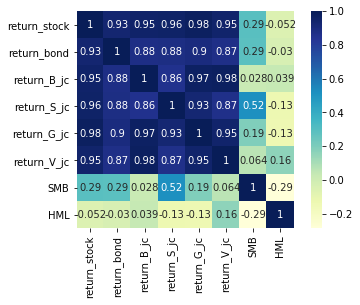

```python
sns.heatmap(corr,annot=True,xticklabels=True,yticklabels=True,square=True,cmap="YlGnBu")
```

由相关性图的结果可以看出巨潮指数的收益之间相关性较强，做回归可能会出现多重共线性问题。

而SMB、HML和MKT之间的相关性不强，回归不容易出现多重共线性问题。

## 回归部分

我们先定义了一个函数以方便我们的回归过程，并将不同基金在不同时间的收益利用不同的方法对自变量的作回归。

```python
def regression(returndata,vari_y,regtype='sharpe'):
    if regtype == 'sharpe':
        data_reg= returndata[['return_B_jc','return_S_jc',
                              'return_G_jc', 'return_V_jc','return_'+vari_y]].dropna()
        x = data_reg[['return_B_jc','return_S_jc',
                              'return_G_jc', 'return_V_jc']]
        x_=x.copy()
        x_['intercept']=1
        y = data_reg['return_'+vari_y]

        model = sm.OLS(y,x)
        #model = sm.OLS(y,x_)
        result=model.fit()
        result.summary()

    if regtype == 'fama':
        data_reg= returndata[['SMB', 'HML', 'MKT_'+vari_y,'return_'+vari_y]].dropna()
        x = data_reg[['SMB', 'HML', 'MKT_'+vari_y]]
        x_=x.copy()
        x_['intercept']=1
        y = data_reg['return_'+vari_y]
        model = sm.OLS(y,x)
        #model = sm.OLS(y,x_)
        result=model.fit()
        result.summary()

    return result
```

### 南方中小盘成长

```python
vari_y='nanfang'
result_nf_s=regression(returndata,vari_y,regtype='sharpe')
result_nf_f=regression(returndata,vari_y,regtype='fama')
```

#### sharpe法

```python
result_nf_s.summary()
```

OLS Regression Results

| Dep. Variable: | return_nanfang | R-squared (uncentered): | 0.406 |
| --- | --- | --- | --- |
| Model: | OLS | Adj. R-squared (uncentered): | 0.404 |
| Method: | Least Squares | F-statistic: | 197.8 |
| Date: | Thu, 31 Dec 2020 | Prob (F-statistic): | 2.91e-129 |
| Time: | 11:34:53 | Log-Likelihood: | 4378.3 |
| No. Observations: | 1161 | AIC: | -8749. |
| Df Residuals: | 1157 | BIC: | -8728. |
| Df Model: | 4 |  |  |
| Covariance Type: | nonrobust |  |  |

|  | coef | std err | t | P>\|t\| | [0.025 | 0.975] |
| --- | --- | --- | --- | --- | --- | --- |
| return_B_jc | 0.0402 | 0.104 | 0.386 | 0.700 | -0.164 | 0.245 |
| return_S_jc | 0.0325 | 0.039 | 0.838 | 0.402 | -0.044 | 0.108 |
| return_G_jc | 0.2310 | 0.077 | 3.006 | 0.003 | 0.080 | 0.382 |
| return_V_jc | 0.0225 | 0.074 | 0.302 | 0.762 | -0.123 | 0.168 |

| Omnibus: | 272.836 | Durbin-Watson: | 1.959 |
| --- | --- | --- | --- |
| Prob(Omnibus): | 0.000 | Jarque-Bera (JB): | 5685.653 |
| Skew: | -0.534 | Prob(JB): | 0.00 |
| Kurtosis: | 13.789 | Cond. No. | 23.3 |

Warnings:  
[1] Standard Errors assume that the covariance matrix of the errors is correctly specified.

#### Fama法

```python
result_nf_f.summary()
```

OLS Regression Results

| Dep. Variable: | return_nanfang | R-squared (uncentered): | 0.144 |
| --- | --- | --- | --- |
| Model: | OLS | Adj. R-squared (uncentered): | 0.142 |
| Method: | Least Squares | F-statistic: | 65.12 |
| Date: | Thu, 31 Dec 2020 | Prob (F-statistic): | 6.54e-39 |
| Time: | 11:34:53 | Log-Likelihood: | 4166.3 |
| No. Observations: | 1161 | AIC: | -8327. |
| Df Residuals: | 1158 | BIC: | -8312. |
| Df Model: | 3 |  |  |
| Covariance Type: | nonrobust |  |  |

|  | coef | std err | t | P>\|t\| | [0.025 | 0.975] |
| --- | --- | --- | --- | --- | --- | --- |
| SMB | -0.0404 | 0.027 | -1.522 | 0.128 | -0.093 | 0.012 |
| HML | -0.3732 | 0.044 | -8.572 | 0.000 | -0.459 | -0.288 |
| MKT_nanfang | 0.0058 | 0.001 | 7.190 | 0.000 | 0.004 | 0.007 |

| Omnibus: | 611.486 | Durbin-Watson: | 1.903 |
| --- | --- | --- | --- |
| Prob(Omnibus): | 0.000 | Jarque-Bera (JB): | 31319.664 |
| Skew: | -1.675 | Prob(JB): | 0.00 |
| Kurtosis: | 28.223 | Cond. No. | 63.4 |

Warnings:  
[1] Standard Errors assume that the covariance matrix of the errors is correctly specified.

#### 结论

```python
regression(returndata.iloc[:-400,],vari_y,regtype='sharpe').summary()
```

OLS Regression Results

| Dep. Variable: | return_nanfang | R-squared (uncentered): | 0.526 |
| --- | --- | --- | --- |
| Model: | OLS | Adj. R-squared (uncentered): | 0.523 |
| Method: | Least Squares | F-statistic: | 209.8 |
| Date: | Thu, 31 Dec 2020 | Prob (F-statistic): | 4.79e-121 |
| Time: | 11:34:53 | Log-Likelihood: | 4369.3 |
| No. Observations: | 761 | AIC: | -8731. |
| Df Residuals: | 757 | BIC: | -8712. |
| Df Model: | 4 |  |  |
| Covariance Type: | nonrobust |  |  |

|  | coef | std err | t | P>\|t\| | [0.025 | 0.975] |
| --- | --- | --- | --- | --- | --- | --- |
| return_B_jc | -0.1543 | 0.018 | -8.407 | 0.000 | -0.190 | -0.118 |
| return_S_jc | -0.0162 | 0.007 | -2.315 | 0.021 | -0.030 | -0.002 |
| return_G_jc | 0.0889 | 0.013 | 6.645 | 0.000 | 0.063 | 0.115 |
| return_V_jc | 0.1478 | 0.015 | 9.984 | 0.000 | 0.119 | 0.177 |

| Omnibus: | 107.762 | Durbin-Watson: | 2.090 |
| --- | --- | --- | --- |
| Prob(Omnibus): | 0.000 | Jarque-Bera (JB): | 702.285 |
| Skew: | 0.428 | Prob(JB): | 3.17e-153 |
| Kurtosis: | 7.628 | Cond. No. | 23.0 |

Warnings:  
[1] Standard Errors assume that the covariance matrix of the errors is correctly specified.

```python
regression(returndata.iloc[:-400,],vari_y,regtype='fama').summary()
```

OLS Regression Results

| Dep. Variable: | return_nanfang | R-squared (uncentered): | 0.397 |
| --- | --- | --- | --- |
| Model: | OLS | Adj. R-squared (uncentered): | 0.394 |
| Method: | Least Squares | F-statistic: | 166.2 |
| Date: | Thu, 31 Dec 2020 | Prob (F-statistic): | 8.57e-83 |
| Time: | 11:34:53 | Log-Likelihood: | 4277.8 |
| No. Observations: | 761 | AIC: | -8550. |
| Df Residuals: | 758 | BIC: | -8536. |
| Df Model: | 3 |  |  |
| Covariance Type: | nonrobust |  |  |

|  | coef | std err | t | P>\|t\| | [0.025 | 0.975] |
| --- | --- | --- | --- | --- | --- | --- |
| SMB | -0.0078 | 0.004 | -1.773 | 0.077 | -0.016 | 0.001 |
| HML | 0.0191 | 0.009 | 2.241 | 0.025 | 0.002 | 0.036 |
| MKT_nanfang | 0.0025 | 0.000 | 20.697 | 0.000 | 0.002 | 0.003 |

| Omnibus: | 127.473 | Durbin-Watson: | 2.027 |
| --- | --- | --- | --- |
| Prob(Omnibus): | 0.000 | Jarque-Bera (JB): | 1105.721 |
| Skew: | 0.461 | Prob(JB): | 7.86e-241 |
| Kurtosis: | 8.833 | Cond. No. | 87.0 |

Warnings:  
[1] Standard Errors assume that the covariance matrix of the errors is correctly specified.

### 安信价值精选

```python
vari_y='anxin'
result_ax_s=regression(returndata,vari_y,regtype='sharpe')
result_ax_f=regression(returndata,vari_y,regtype='fama')
```

#### sharpe法

```python
result_ax_s.summary()
```

OLS Regression Results

| Dep. Variable: | return_anxin | R-squared (uncentered): | 0.895 |
| --- | --- | --- | --- |
| Model: | OLS | Adj. R-squared (uncentered): | 0.895 |
| Method: | Least Squares | F-statistic: | 3259. |
| Date: | Thu, 31 Dec 2020 | Prob (F-statistic): | 0.00 |
| Time: | 11:34:53 | Log-Likelihood: | 5987.7 |
| No. Observations: | 1532 | AIC: | -1.197e+04 |
| Df Residuals: | 1528 | BIC: | -1.195e+04 |
| Df Model: | 4 |  |  |
| Covariance Type: | nonrobust |  |  |

|  | coef | std err | t | P>\|t\| | [0.025 | 0.975] |
| --- | --- | --- | --- | --- | --- | --- |
| return_B_jc | 0.3124 | 0.063 | 4.968 | 0.000 | 0.189 | 0.436 |
| return_S_jc | 0.0984 | 0.022 | 4.417 | 0.000 | 0.055 | 0.142 |
| return_G_jc | 0.4901 | 0.047 | 10.436 | 0.000 | 0.398 | 0.582 |
| return_V_jc | 0.0034 | 0.047 | 0.071 | 0.943 | -0.090 | 0.096 |

| Omnibus: | 124.816 | Durbin-Watson: | 1.790 |
| --- | --- | --- | --- |
| Prob(Omnibus): | 0.000 | Jarque-Bera (JB): | 662.351 |
| Skew: | -0.129 | Prob(JB): | 1.49e-144 |
| Kurtosis: | 6.211 | Cond. No. | 21.1 |

Warnings:  
[1] Standard Errors assume that the covariance matrix of the errors is correctly specified.

#### Fama法

```python
result_ax_f.summary()
```

OLS Regression Results

| Dep. Variable: | return_anxin | R-squared (uncentered): | 0.887 |
| --- | --- | --- | --- |
| Model: | OLS | Adj. R-squared (uncentered): | 0.887 |
| Method: | Least Squares | F-statistic: | 4017. |
| Date: | Thu, 31 Dec 2020 | Prob (F-statistic): | 0.00 |
| Time: | 11:34:53 | Log-Likelihood: | 5933.6 |
| No. Observations: | 1532 | AIC: | -1.186e+04 |
| Df Residuals: | 1529 | BIC: | -1.185e+04 |
| Df Model: | 3 |  |  |
| Covariance Type: | nonrobust |  |  |

|  | coef | std err | t | P>\|t\| | [0.025 | 0.975] |
| --- | --- | --- | --- | --- | --- | --- |
| SMB | -0.2373 | 0.013 | -18.640 | 0.000 | -0.262 | -0.212 |
| HML | -0.1980 | 0.026 | -7.696 | 0.000 | -0.248 | -0.148 |
| MKT_anxin | 0.9360 | 0.009 | 105.988 | 0.000 | 0.919 | 0.953 |

| Omnibus: | 91.332 | Durbin-Watson: | 1.792 |
| --- | --- | --- | --- |
| Prob(Omnibus): | 0.000 | Jarque-Bera (JB): | 211.200 |
| Skew: | 0.356 | Prob(JB): | 1.38e-46 |
| Kurtosis: | 4.674 | Cond. No. | 3.55 |

Warnings:  
[1] Standard Errors assume that the covariance matrix of the errors is correctly specified.

### 嘉实研究阿尔法

#### Sharpe法

```python
vari_y='jiashi'
result_js_s=regression(returndata,vari_y,regtype='sharpe')
result_js_f=regression(returndata,vari_y,regtype='fama')
```

```python
result_js_s.summary()
```

OLS Regression Results

| Dep. Variable: | return_jiashi | R-squared (uncentered): | 0.928 |
| --- | --- | --- | --- |
| Model: | OLS | Adj. R-squared (uncentered): | 0.927 |
| Method: | Least Squares | F-statistic: | 5592. |
| Date: | Thu, 31 Dec 2020 | Prob (F-statistic): | 0.00 |
| Time: | 11:34:53 | Log-Likelihood: | 7240.9 |
| No. Observations: | 1749 | AIC: | -1.447e+04 |
| Df Residuals: | 1745 | BIC: | -1.445e+04 |
| Df Model: | 4 |  |  |
| Covariance Type: | nonrobust |  |  |

|  | coef | std err | t | P>\|t\| | [0.025 | 0.975] |
| --- | --- | --- | --- | --- | --- | --- |
| return_B_jc | 0.5143 | 0.048 | 10.764 | 0.000 | 0.421 | 0.608 |
| return_S_jc | 0.3275 | 0.017 | 19.628 | 0.000 | 0.295 | 0.360 |
| return_G_jc | 0.1156 | 0.036 | 3.238 | 0.001 | 0.046 | 0.186 |
| return_V_jc | -0.0732 | 0.036 | -2.036 | 0.042 | -0.144 | -0.003 |

| Omnibus: | 1125.811 | Durbin-Watson: | 1.733 |
| --- | --- | --- | --- |
| Prob(Omnibus): | 0.000 | Jarque-Bera (JB): | 138354.029 |
| Skew: | 2.081 | Prob(JB): | 0.00 |
| Kurtosis: | 46.373 | Cond. No. | 21.1 |

Warnings:  
[1] Standard Errors assume that the covariance matrix of the errors is correctly specified.

#### Fama法

```python
result_js_f.summary()
```

OLS Regression Results

| Dep. Variable: | return_jiashi | R-squared (uncentered): | 0.927 |
| --- | --- | --- | --- |
| Model: | OLS | Adj. R-squared (uncentered): | 0.927 |
| Method: | Least Squares | F-statistic: | 7360. |
| Date: | Thu, 31 Dec 2020 | Prob (F-statistic): | 0.00 |
| Time: | 11:34:53 | Log-Likelihood: | 7230.1 |
| No. Observations: | 1749 | AIC: | -1.445e+04 |
| Df Residuals: | 1746 | BIC: | -1.444e+04 |
| Df Model: | 3 |  |  |
| Covariance Type: | nonrobust |  |  |

|  | coef | std err | t | P>\|t\| | [0.025 | 0.975] |
| --- | --- | --- | --- | --- | --- | --- |
| SMB | -0.1569 | 0.009 | -16.875 | 0.000 | -0.175 | -0.139 |
| HML | -0.1950 | 0.019 | -10.158 | 0.000 | -0.233 | -0.157 |
| MKT_jiashi | 0.3814 | 0.003 | 141.732 | 0.000 | 0.376 | 0.387 |

| Omnibus: | 529.041 | Durbin-Watson: | 1.846 |
| --- | --- | --- | --- |
| Prob(Omnibus): | 0.000 | Jarque-Bera (JB): | 12336.699 |
| Skew: | 0.863 | Prob(JB): | 0.00 |
| Kurtosis: | 15.896 | Cond. No. | 8.05 |

Warnings:  
[1] Standard Errors assume that the covariance matrix of the errors is correctly specified.

## 滚动窗口基金风格分析

作出函数，可以调整滚动时间窗口大小进行绘图。以下展示的解决均为时间窗口设置为90天的作图结果，如果需要，可以很快地利用代码进行改变。

```python
def rolling_reg(returndata,vari_y,regtype='sharpe',window=90):
    ######vari_y为回归应变量基金，regtype为回归类型，window为滚动窗口时长
    if regtype == 'sharpe':
        data_reg= returndata[['return_B_jc','return_S_jc', 'return_G_jc',
                     'return_V_jc','return_'+vari_y]].dropna()
        data_reg['rolling_S']=np.nan
        data_reg['rolling_B']=np.nan
        data_reg['rolling_H']=np.nan
        data_reg['rolling_L']=np.nan

        for i in range(len(data_reg)-window):
            ####滚动作回归
            data_reg_=data_reg.iloc[i:i+window,].copy()
            x = data_reg_[['return_B_jc','return_S_jc', 'return_G_jc','return_V_jc']]
            y = data_reg_['return_'+vari_y]
            model = sm.OLS(y,x)
            result=model.fit()

            data_reg['rolling_S'].iloc[i+window,]=result.params['return_S_jc']
            data_reg['rolling_B'].iloc[i+window,]=result.params['return_B_jc']
            data_reg['rolling_H'].iloc[i+window,]=result.params['return_V_jc']
            data_reg['rolling_L'].iloc[i+window,]=result.params['return_G_jc']
            data_reg['rolling_S_B']=data_reg['rolling_S']-data_reg['rolling_B']
            data_reg['rolling_H_L']=data_reg['rolling_H']-data_reg['rolling_L']

        plt.figure(figsize=(16,8))
        plt.title('rolling regression (sharpe) for '+vari_y+' windows: '+str(window))
        plt.plot(data_reg[['rolling_S','rolling_B','rolling_H','rolling_L']])
        plt.legend(data_reg[['rolling_S','rolling_B','rolling_H','rolling_L']])
        plt.axhline(y=0,c="black")
        plt.show()

        plt.figure(figsize=(16,8))
        plt.title('rolling regression (sharpe) for '+vari_y+' windows: '+str(window))
        plt.plot(data_reg[['rolling_S_B','rolling_H_L']])
        plt.legend(data_reg[['rolling_S_B','rolling_H_L']])
        plt.axhline(y=0,c="black")
        plt.show()


        # data_reg[['rolling_S','rolling_B','rolling_H','rolling_L']].plot()

    if regtype == 'fama':
        data_reg= returndata[['SMB', 'HML', 'MKT_'+vari_y,'return_'+vari_y]].dropna()
        data_reg['rolling_SMB']=np.nan
        data_reg['rolling_HML']=np.nan
        data_reg['rolling_MKT']=np.nan

        for i in range(len(data_reg)-window):
            #####滚动作回归
            data_reg_=data_reg.iloc[i:i+window,].copy()
            x = data_reg_[['SMB', 'HML', 'MKT_'+vari_y]]
            y = data_reg_['return_'+vari_y]
            model = sm.OLS(y,x)
            result=model.fit()

            data_reg['rolling_SMB'].iloc[i+window,]=result.params['SMB']
            data_reg['rolling_HML'].iloc[i+window,]=result.params['HML']
            data_reg['rolling_MKT'].iloc[i+window,]=result.params['MKT_'+vari_y]


        plt.figure(figsize=(16,8))
        plt.title('rolling regression(fama) for '+vari_y+' windows: '+str(window))
        plt.plot(data_reg[['rolling_SMB','rolling_HML','rolling_MKT']])
        plt.legend(['SMB','HML','MKT'])
        plt.axhline(y=0,c="black")
        plt.show()

        #data_reg[['rolling_SMB','rolling_HML','rolling_MKT']].plot()

    return data_reg
```

### 南方中小盘成长

#### sharpe法

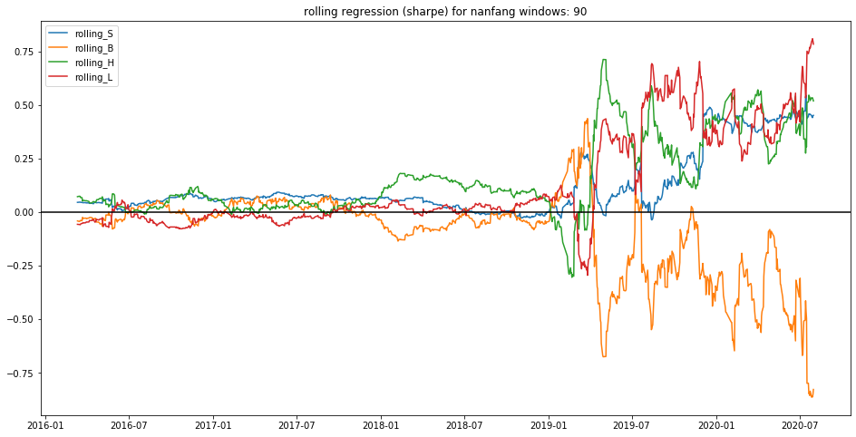

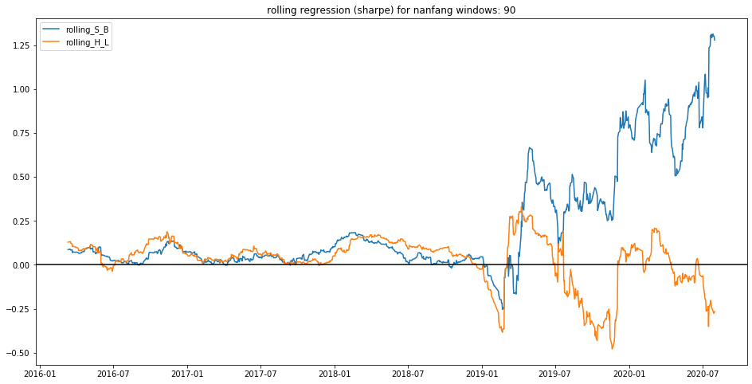

```python
vari_y='nanfang'
data_reg_nf_s=rolling_reg(returndata,vari_y,regtype='sharpe',window=90)
```

#### Fama法

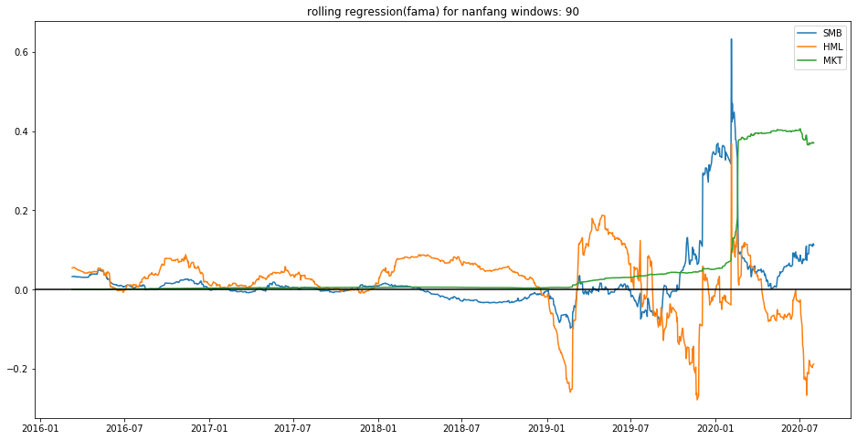

```python
data_reg_nf_f=rolling_reg(returndata,vari_y,regtype='fama',window=90)
```

#### 结论

由于数据本身存在一定的问题，2019年之前的结果不具有参考性。2019年之后，南方中小盘成长基金持仓一直以股票型为主。在样本期间内组合的运行趋势和市场整体一致。2019年上半年风格由成长股切换为价值股，下半年又转回成长股。2020年后也曾向价值股发生过偏转。2019年中以前，基金一直在大盘小盘股间保持平衡，但是2019年下半年开始，基金风格突变为小盘股，在2020年之后又回归到中小盘股的风格。

结合基金网上披露的基本描述信息，基金运用以下策略：

- 资产配置上，作为股票型证券投资基金,采用“自上而下”的策略进行基金的大类资产配置。
- 股票投资策略上，基金采用以下标准对股票进行筛选,确定中小盘股票的初步备选投资对象: 将市场所有股票按流通市值从小到大进行排序,流通市值累计达到全部上市公司股票市场总流通市值前50%的股票,作为中小盘股票。剔除投资限制中规定的禁止投资股票,以剩余的中小盘股票建立基础股票池。在基础股票池基础上,基金主要采取定性和定量相结合的方式,对基础股票池中的股票进行深入研究,精选符合投资理念的成长型优质股票。基金将首先采用定量分析指标,筛选出**成长潜力较大的中小市值**上市公司基金利用相对价值评估,形成可投资的股票组合。

### 安信价值精选

#### Sharpe法

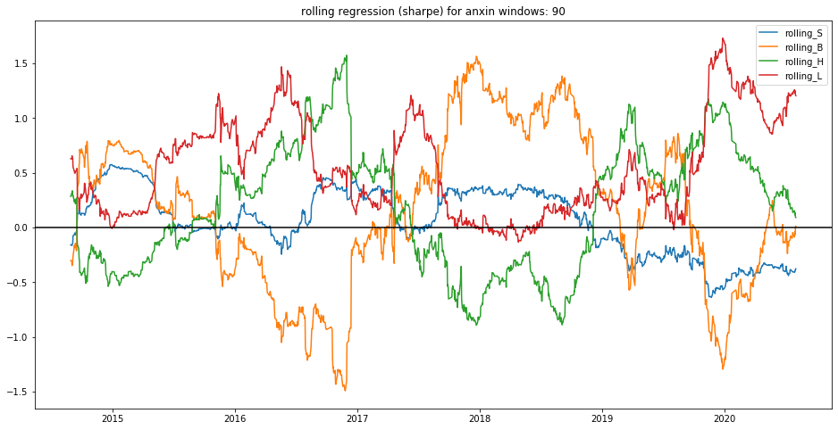

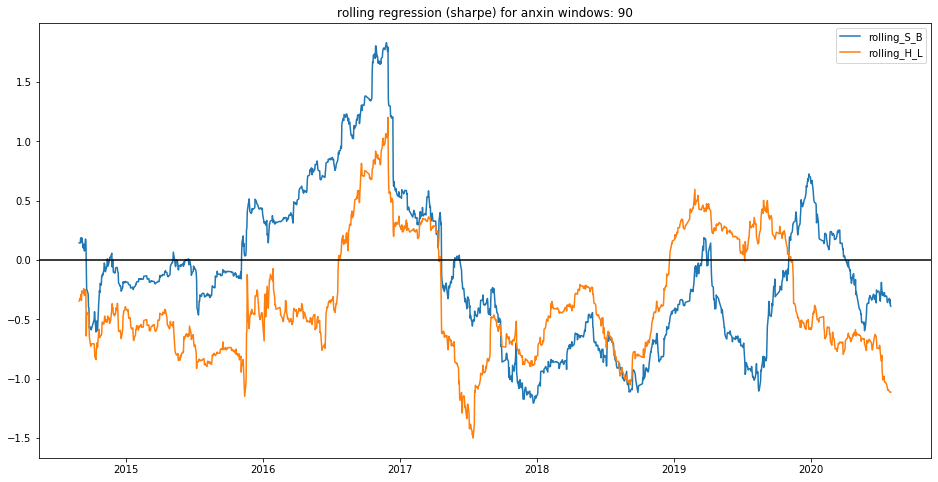

```python
vari_y='anxin'
data_reg_ax_s=rolling_reg(returndata,vari_y,regtype='sharpe',window=90)
```

#### Fama法

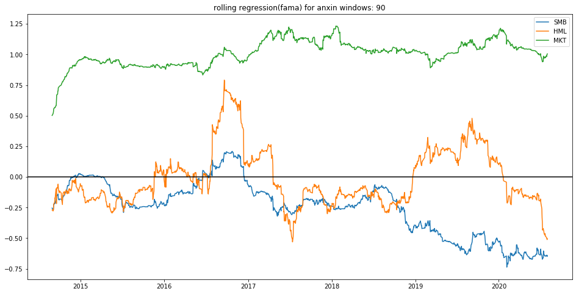

```python
data_reg_ax_f=rolling_reg(returndata,vari_y,regtype='fama',window=90)
```

#### 结论

根据介绍，基金策略在大类资产和股票投资上的要点如下：

- 资产配置策略基金的资产配置策略以基于宏观、政策及市场分析的定性研究为主,重点关注包括GDP增速、投资增速、货币供应、通胀率和利率等宏观和政策指标,同时结合定量分析的方法,对未来各大类资产的风险和预期收益率进行分析评估,制定股票、债券、现金等大类资产之间的配置比例、调整原则和调整范围。
- 股票投资策略方面，基金所称的价值型股票,即在深入的基本面研究的基础上,股价相对于内在价值明显低估的股票;它可以是由于经济周期原因或市场情绪原因造成的低估值股票,也可以是壁垒明确、具有持续盈利增长前景、具有吸引人的合理价格的股票。基金的股票投资将在行业研究的基础上,通过**自上而下和自下而上相结合**的方法,精选内在价值被低估的股票构建投资组合。 行业选择策略上，根据中国经济增长的阶段和周期特征,结合国家产业政策和区域发展政策,分析各行业的景气度和发展前景、行业竞争结构和行业盈利模式等,评估各行业的相对估值水平和投资价值。重点关注行业的生命周期阶段和增长空间、行业波动特点和影响要素、行业内外部环境和产业链上下游关系等等。 基金的股票资产主要投资于**价值型股票**,坚持深入的基本面分析和坚持安全边际，金采用定性分析和定量分析相结合的方法,综合公开信息(包括财务数据)、第三方研究报告和研究员实地调研的结果,对目标上市公司的经营管理与投资价值进行深入研究,并根据定量财务分析和盈利预测挖掘价值被低估的上市公司作为重点投资对象。

### 嘉实研究阿尔法

#### Sharpe法

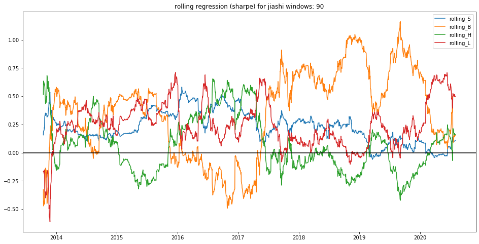

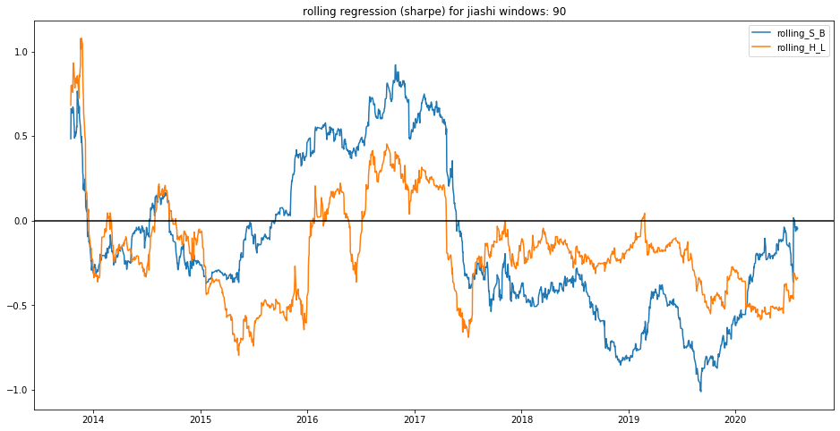

```python
vari_y='jiashi'
data_reg_js_s=rolling_reg(returndata,vari_y,regtype='sharpe',window=90)
```

#### Fama法

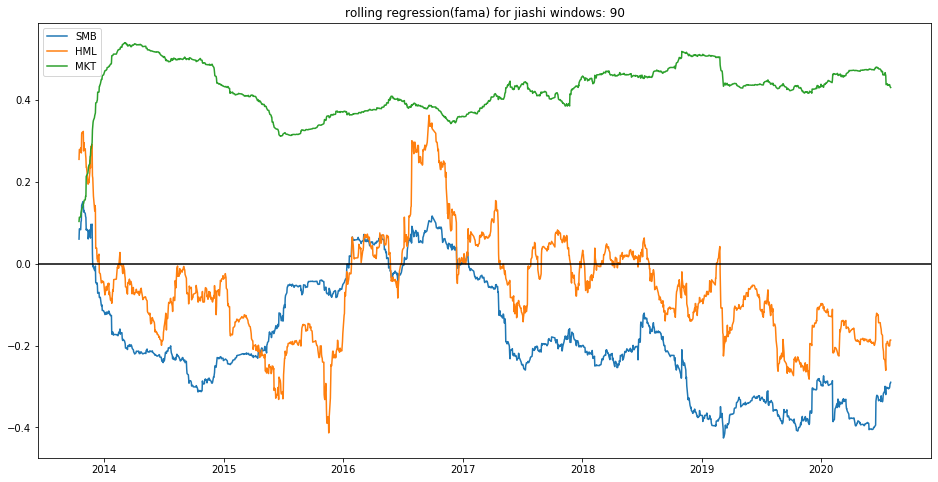

```python
data_reg_js_f=rolling_reg(returndata,vari_y,regtype='fama',window=90)
```

#### 结论

作为一支股票型基金，嘉实研究阿尔法基金持仓一直以股票型为主。从图中一直保持在0.4左右的'MKT'可以中看出嘉实研究阿尔法基金在样本期间内组合的运行趋势和市场整体一致。2014年到2016年，基金风格整体偏向大盘成长型基金，2016年到2017年间有小转动，向小盘价值型基金略有偏移。2017年之后风格仍然回归大盘成长型股票。

关于本基金策略在大类资产和股票投资上的要点如下：

- 大类资产配置上，作为较高仓位的股票基金,从宏观面、政策面、基本面和资金面等四个纬度进行综合分析,根据市场情况在本基金的投资范围内进行适度动态配置,在控制风险的前提下,通过对基本面的深入研究谋求基金投资组合。
- 股票投资策略上，采用“自下而上”的股票精选策略,坚持以深入细致的基本面研究为选股的基本原则并在研究团队的模拟组合基础上精选个股。将研究团队划分为不同的研究小组,其研究范围覆盖了全部行业。因此,选股将不再局限于个别行业或者单一风格,选股类型也更加丰富,包括成长股、价值股等不同类型。

### pyecharts画图

```python
from pyecharts.globals import CurrentConfig, OnlineHostType
CurrentConfig.ONLINE_HOST = OnlineHostType.NOTEBOOK_HOST
from pyecharts.globals import SymbolType
from pyecharts.charts import Sankey,Grid,Line,Page,WordCloud
import pyecharts.options as opts
```

```python
def plot_sharpe(data_reg):
    plot1 = (
        Line()
        .add_xaxis(xaxis_data=data_reg.index)
        .add_yaxis(
            series_name="rolling_S",
            y_axis=data_reg.rolling_S,
            label_opts=opts.LabelOpts(is_show=False),
        )
        .add_yaxis(
            series_name="rolling_B",
            y_axis=data_reg.rolling_B,
            label_opts=opts.LabelOpts(is_show=False),
        )
        .add_yaxis(
            series_name="rolling_H",
            y_axis=data_reg.rolling_H,
            label_opts=opts.LabelOpts(is_show=False),
        )
        .add_yaxis(
            series_name="rolling_L",
            y_axis=data_reg.rolling_L,
            label_opts=opts.LabelOpts(is_show=False),
        )

        .set_global_opts(
            title_opts=opts.TitleOpts(title="Sharpe图",),
            tooltip_opts=opts.TooltipOpts(trigger="axis"),
            yaxis_opts=opts.AxisOpts(
                type_="value",
                axistick_opts=opts.AxisTickOpts(is_show=True),
                splitline_opts=opts.SplitLineOpts(is_show=True),
            ),
            xaxis_opts=opts.AxisOpts(type_="category", boundary_gap=False),
        )
        .render_notebook()
    )

    plot2 = (
        Line()
        .add_xaxis(xaxis_data=data_reg.index)
        .add_yaxis(
            series_name="rolling_S_B",
            y_axis=data_reg.rolling_S_B,
            label_opts=opts.LabelOpts(is_show=False),
        )
        .add_yaxis(
            series_name="rolling_H_L",
            y_axis=data_reg.rolling_H_L,
            label_opts=opts.LabelOpts(is_show=False),
        )

        .set_global_opts(
            title_opts=opts.TitleOpts(title="Sharpe图",),
            tooltip_opts=opts.TooltipOpts(trigger="axis"),
            yaxis_opts=opts.AxisOpts(
                type_="value",
                axistick_opts=opts.AxisTickOpts(is_show=True),
                splitline_opts=opts.SplitLineOpts(is_show=True),
            ),
            xaxis_opts=opts.AxisOpts(type_="category", boundary_gap=False),
        )
        .render_notebook()
    )
    return plot1,plot2
```

```python
plot1,plot2=plot_sharpe(data_reg_ax_s)
plot2
```

```python
def plot_fama(data_reg):
    plot = (
        Line()
        .add_xaxis(xaxis_data=data_reg.index)
        .add_yaxis(
            series_name="SMB",
            y_axis=data_reg.rolling_SMB,
            label_opts=opts.LabelOpts(is_show=False),
        )
        .add_yaxis(
            series_name="HML",
            y_axis=data_reg.rolling_HML,
            label_opts=opts.LabelOpts(is_show=False),
        )
        .add_yaxis(
            series_name="MKT",
            y_axis=data_reg.rolling_MKT,
            label_opts=opts.LabelOpts(is_show=False),
        )

        .set_global_opts(
            title_opts=opts.TitleOpts(title="Fama图",),
            tooltip_opts=opts.TooltipOpts(trigger="axis"),
            yaxis_opts=opts.AxisOpts(
                type_="value",
                axistick_opts=opts.AxisTickOpts(is_show=True),
                splitline_opts=opts.SplitLineOpts(is_show=True),
            ),
            xaxis_opts=opts.AxisOpts(type_="category", boundary_gap=False),
        )
        .render_notebook()
    )
    return plot
```

```python
plot_fama(data_reg_ax_f)
```

## 后续改进

后续可在两个两个方向上进行改进：

- 在传统的多元回归中，自变量系数没有约束。而对于投资者所关注的基金投资风格而言，每类资产“夏普风格权重”的高低以及正负号都应该符合基金的持仓特征。后续可引入带约束的自变量系数，再进行回归求解。
- 与传统的多元线性模型一样，该模型也会存在多种共线性问题。我们可以从第一部分的相关性结果中看出，使用sharpe法时多重共线性问题存在且较为严重。因为在该模型中可能存在不同的风格因子是在同一资产类别下的不同投资方法，在这种情况下因子之间的相关性就会很高。若不进行一定的处理，就会出现系数失真和模型失灵。后续可针对多重共线性问题利用逐步回归法或者岭回归。